## Comparative Stock Analysis Volume - II

### Introduction

If you are interested in intra day trading or you want to know or identify patterns in stock market, this article is for you. In last Descriptive analysis was provided for comparative analysis on stocks. In this post, emphasis is given on identifying patterns in order to know how a stock behaves which is very important for stock trading. Later part of the article will show how to predict stock prices using the conventional ARIMA (Auto-Regressive intensive Moving Average Method) methodolgy from Time Series Analysis and Regression Model.

### Setting up the System

#### Required Packages

- Quandl Data Download
- tidyverse Use of tibble to group and perform single operation on multiple groups
- tidyquant Time Series and Financial functions to perform the analysis

### Bollinger Band

The Bollinger Band was introduce by John Bollinger in 1980s, the Band shows the volatility of stock. Volatility is based on standard deviation, which changes as volatility increases or decreases. The Volatility bands are placed above and below the moving average line. The wider the gap between the bands, higher is the degree of volatility. On the other hand, as the wideness within the band decreases, lower is the degree of volatility of the stock. At times, the wideness within the band is constant over a period of time, which shows the constant behaviour of a certain stock over the period of time.

There are three lines in the Bollinger Band,

Bollinger Bands consist of:

- The middle line with N-period moving average (MA);20-day SMA
- An upper band at K times an N-period standard deviation above the moving average;
- 20-day SMA + (20-day standard deviation of price x 2)
- A lower band at K times an N-period standard deviation below the moving average;
- 20-day SMA - (20-day standard deviation of price x 2)

Note: SMA is Simple Moving Average, K and N period is ususally set at 20 days. Standard deviation is taken for 20 days. The upper and lower band are placed 2 units above and below respectively.

Below image is the typical example for Bollinger Band. This shows the volatility of Axis Bank stock for the period of 1 year from 1st Spetember, 2016 to 1st September, 2017. The gap was higher in the months of September till December.

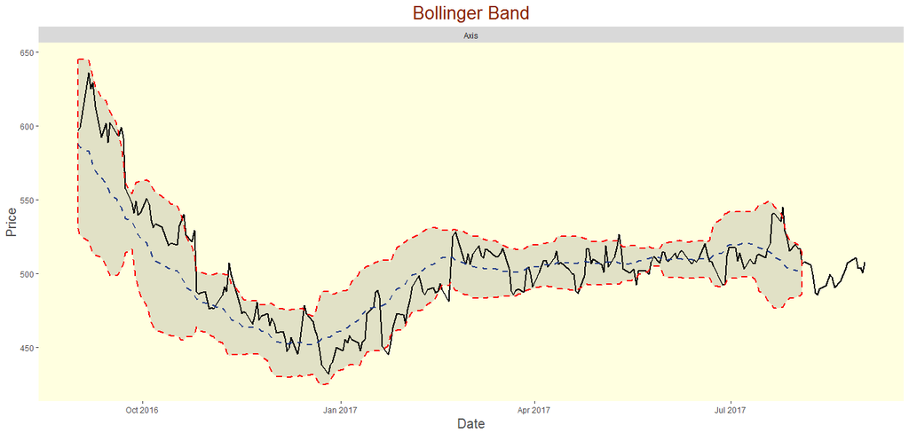

#### Trading with Bollinger Bands

In this section, we will discuss few aspects of Bollinger Band. This information can be used in different stock trading.

- If an uptrend is strong, then stock touches the upper band on regular basis and remain above the middle line.This signals the strong movement towards North.
- If downtrend is strong, then stong touches the lower band on regular basis and remain below the middle line. This signals strong southward movement.
- During the upward trend the price should not be below the lower band otherwise its signalling the reverse movement.
- During the downward trend, if the price move above the upper band then it signals Northward movement.

The study will discuss the above points along with the identification of popular patterns like “W - Bottoms” & “M - Tops” in bollinger band.

### Keep it Clean!

We will keep the data clean with tidyverse. In this section we will first download the data with the help of Quandl package and then manipulate the dataframe with tidyverse to get our desired dataset,

```r
## Required Packages
library(Quandl)
library(tidyverse)
library(tidyquant)
library(timetk)
library(forecast)
library(gridExtra)
```

#### Code Break up for Quandl and Quandl API key,

Please read my previous post on [Comparative Stock Analysis Vol-I](https://www.analyticsvidhya.com/blog/2017/09/comparative-stock-analysis/)

```r
## Setup the Quandl Free Acount and API Key, Please copy and paste the API key in order to #authinticate

Quandl.api_key("xRPW5yp-5pmJCQZqgNVN")

## Download the data Set
ICICI = Quandl("NSE/ICICIBANK",collapse="daily",start_date="2016-09-01",type="raw")
PNB= Quandl("NSE/PNB",collapse="daily",start_date="2016-09-01",type="raw")
Axis=Quandl("NSE/AXISBANK",collapse="daily",start_date="2016-09-01",type="raw")
Canara=Quandl("NSE/CANBK",collapse="daily",start_date="2016-09-01",type="raw")
BOB=Quandl("NSE/BANKBARODA",collapse="daily",start_date="2016-09-01",type="raw")
SBI=Quandl("NSE/SBIN",collapse="daily",start_date="2016-09-01",type="raw")

## Add another ("Stock") coloumn in Datasets using cbind command

ICICI<-cbind(ICICI,Stock="")
PNB<-cbind(PNB,Stock="")
Axis<-cbind(Axis,Stock="")
SBI<-cbind(SBI,Stock="")
Canara<-cbind(Canara,Stock="")
BOB<-cbind(BOB,Stock="")

## Paste the stock name in stock coloumn

ICICI$Stock<-paste(ICICI$Stock,"ICICI",sep="")
PNB$Stock<-paste(PNB$Stock,"PNB",sep="")
Axis$Stock<-paste(Axis$Stock,"Axis",sep="")
SBI$Stock<-paste(SBI$Stock,"SBI",sep="")
Canara$Stock<-paste(Canara$Stock,"Canara",sep="")
BOB$Stock<-paste(BOB$Stock,"BOB",sep="")

## Consolidate under one dataset

Master_Data<-rbind(ICICI,PNB,Axis,SBI,Canara,BOB)

## Coerce the Date variable into as.Date from character

Master_Data$Date<-as.Date(Master_Data$Date)

end<-ymd("2017-09-01")
start<-ymd("2016-09-01")

Master_Data<-Master_Data%>%
  tibble::as_tibble() %>%
group_by(Stock)
```

### Identification of Patterns

#### Signal W - Bottoms

A “W-Bottom” forms in a downtrend and involves two reaction lows. In particular, Bollinger looks for W-Bottoms where the second low is lower than the first but holds above the lower band. There are four steps to confirm Bollinger “W - Bottoms”,

- First, a reaction low forms. This low is usually,below the lower band (Not Always).
- Secondly, there is a bounce towards the middle band.
- Thirdly, there is a new price low in the security. This low holds above the lower band.
- Fourth, the pattern is confirmed with a strong move off the second low and a resistance break.

Below image is the “W-Bottoms” identification for BOB (Bank of Baroda). Both of the W-Bottoms are followed by strong northward move in february and May, 2017 respectively.

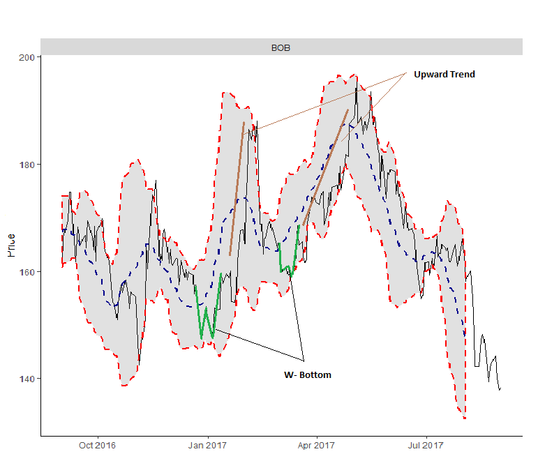

#### Signal: M-Tops

An M-Top is similar to a double top. M-Tops are reversal signals from upward trend into a downward trend. The first high can be higher or lower than the second high. Initially there is a wave higher, which gets close to or move above the upper band. Then price will move downward to middle band and then continues northward journey, might or might not touch the upper band (at times it goes above the previous high) and then does not close above the upper band.

Bollinger suggests looking for signs of non-confirmation when a security is making new highs.A non-confirmation occurs with three steps.

- First, a security creates a reaction high above the upper band.
- Second, there is a pullback towards the middle band.
- Third, prices move above the prior high but fail to reach the upper band. This is a warning sign. The inability of the second reaction high to reach the upper band shows waning momentum, which can foreshadow a trend reversal. Final confirmation comes with a support break or bearish indicator signal.

Below is the image for MTOPS signal for SBI (State Bank Of India) stock in NSE over the period of one year starting from 1st sept, 2016 to 1st sept, 2017. Each of the MTops are followed by decline in prices in the months of Nov-Dec, May and August.

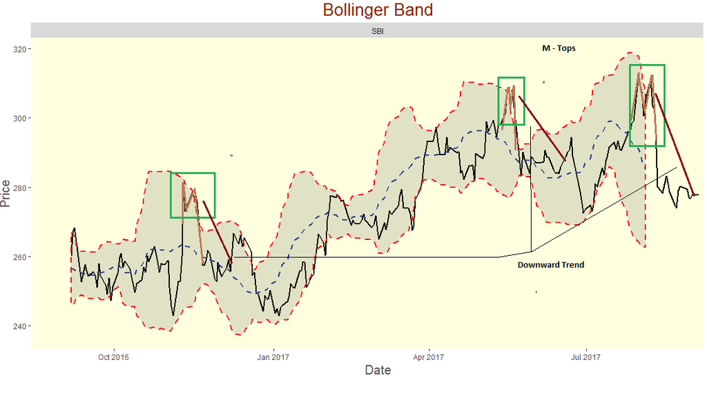

### Volatility of Bank Stocks

Let us visualise the volatility (gap between the upper and lower band) and also try to identify the patterns / signals in our six selected bank stocks.

[figure not shown]

```r
 ## Visualisation of BBand in ggplot2

 Master_Data%>%filter(Stock=="ICICI"|Stock=="PNB")%>%ggplot(aes(x=Date,y=Close))+
    geom_line(size=1)+
    geom_bbands(aes(high = High, low = Low, close = Close), ma_fun = SMA, sd=2,n = 20,size=0.75,
        color_ma = "royalblue4", color_bands = "red1")+
    coord_x_date(xlim = c(start, end), expand = TRUE)+
    facet_wrap(~ Stock, scales = "free_y")+
    labs(title = "Bollinger Band", x = "Date",y="Price") +
  theme(text = element_text(family = 'Gill Sans', color = "#444444",hjust=0.5)
        ,panel.background = element_rect(fill = 'lightyellow')
        ,panel.grid.minor = element_blank(),
        ,panel.grid.major = element_blank()
        ,plot.title = element_text(size = 20,hjust=0.5,colour="orangered4")
        ,axis.title = element_text(size = 18, color = '#555555')
        ,axis.title.y = element_text(hjust=0.5,size=15)
        ,axis.title.x = element_text(hjust = 0.5,size=15)
        ) +
theme(legend.position="none")
```

[output not shown]

- 1. MTOP formed in Nov (Signalling downward trending).Prices declined to a new low till January 2017.
- 2. Volatility for the ICICI stock over the epriod of 1 year was very high in october, 2016. It was constant for the month of 3 months (march to may,2017) when the prices were in the range of Rs 265 to Rs 285.
- 3. PNB Stock shows mutiple MTOPS over the period of 1 year followed by strong downward trend.
- 4. PNB has high volatility, it shows erratic upward and downward movement through out the year.It touches to a new low below RS 120 in Jan 2017 and reaches a new high RS 175 in the month of May, 2017.

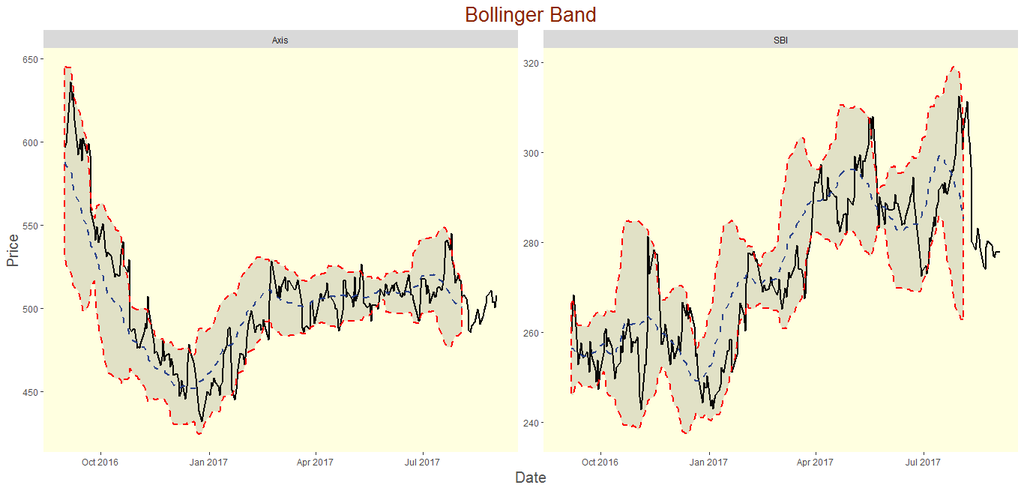

```r
Master_Data%>%filter(Stock=="Axis"|Stock=="SBI")%>%ggplot(aes(x=Date,y=Close))+
    geom_line(size=1)+
    geom_bbands(aes(high = High, low = Low, close = Close), ma_fun = SMA, sd=2,n = 20,size=0.75,
        color_ma = "royalblue4", color_bands = "red1")+
    coord_x_date(xlim = c(start, end), expand = TRUE)+
    facet_wrap(~ Stock, scales = "free_y")+
    labs(title = "Bollinger Band", x = "Date",y="Price") +
  theme(text = element_text(family = 'Gill Sans', color = "#444444",hjust=0.5)
        ,panel.background = element_rect(fill = 'lightyellow')
        ,panel.grid.minor = element_blank(),
        ,panel.grid.major = element_blank()
        ,plot.title = element_text(size = 20,hjust=0.5,colour="orangered4")
        ,axis.title = element_text(size = 18, color = '#555555')
        ,axis.title.y = element_text(hjust=0.5,size=15)
        ,axis.title.x = element_text(hjust = 0.5,size=15)
        ) +
theme(legend.position="none")
```

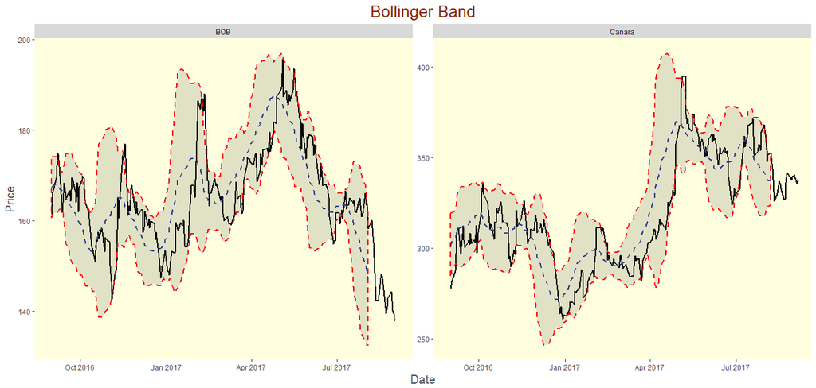

```r
Master_Data%>%filter(Stock=="Canara"|Stock=="BOB")%>%ggplot(aes(x=Date,y=Close))+
    geom_line(size=1)+
    geom_bbands(aes(high = High, low = Low, close = Close), ma_fun = SMA, sd=2,n = 20,size=0.75,
        color_ma = "royalblue4", color_bands = "red1")+
    coord_x_date(xlim = c(start, end), expand = TRUE)+
    facet_wrap(~ Stock, scales = "free_y")+
    labs(title = "Bollinger Band", x = "Date",y="Price") +
  theme(text = element_text(family = 'Gill Sans', color = "#444444",hjust=0.5)
        ,panel.background = element_rect(fill = 'lightyellow')
        ,panel.grid.minor = element_blank(),
        ,panel.grid.major = element_blank()
        ,plot.title = element_text(size = 20,hjust=0.5,colour="orangered4")
        ,axis.title = element_text(size = 18, color = '#555555')
        ,axis.title.y = element_text(hjust=0.5,size=15)
        ,axis.title.x = element_text(hjust = 0.5,size=15)
        ) +
theme(legend.position="none")
```

#### Good Read

Before we move to next part, it will be good to hear get more information on the Bollinger Band and related identification patterns. Below are the links to the resources (Free),

- [John Bollinger Lectures and Videos](https://www.bollingerbands.com/videos-articles-interviews)
- [Stock Charts School](http://stockcharts.com/articles/dont_ignore_this_chart/2017/09/bp-bp-breaks-out-to-new-two-year-highs.html)

## Prediction

#### Prediction of Stock Prices

- Regression Approach In the last post, we have seen that the stock prices is also dependent on the traded quantity, but direction can be either ways. In our analysis, we will take consideration of these movements.
- ARIMA (Auto Regressive Intensive Moving Average)

We will also analyse the random part of the stock price movement, so called white noise and will include in our prediction model.

There is also available study on white noise on Analytics Vidya (Tavish Srivastava). Please click [here](https://www.analyticsvidhya.com/blog/2015/12/complete-tutorial-time-series-modeling/) to get more information.

The following points are the steps to arrive at Predictions

Note: ggplot shows the prediction and actual prices. Predcition prices has the band for lower and upper limit.

[figure not shown]

```r
    ## Download the data Set
PNB = Quandl("NSE/ICICIBANK",collapse="monthly",start_date="2016-09-01",type="raw")
Axis=Quandl("NSE/AXISBANK",collapse="monthly",start_date="2016-09-01",type="raw")

## Convert the PNB & Axis Data Set into df for regression model

PNB_df=PNB
Axis_df=Axis
colnames(PNB_df)<-c("Date","Open","High","Low","Last","Close","TTQ","Turnover")
colnames(Axis_df)<-c("Date","Open","High","Low","Last","Close","TTQ","Turnover")

## Change the scale of Trade quantity

PNB_df$TTQ<-PNB_df$TTQ/100000
Axis_df$TTQ<-Axis_df$TTQ/100000

## Regression models

m1=lm(PNB_df$Close~PNB_df$High+PNB_df$Low+PNB_df$TTQ)

p1.df=as.data.frame(predict(m1,interval="predict"))

m3=lm(Axis_df$Close~Axis_df$High+Axis_df$Low+Axis_df$TTQ)

p3.df=as.data.frame(predict(m3, interval="predict"))

## Forecast using ARIMA to take out the seasonality and cyclic part of the stock

m2=arima(diff(PNB_df$Close),order=c(1,0,0))
m4=arima(diff(Axis_df$Close),order=c(1,0,0))
p2.df=as.data.frame(predict(m2,n.ahead=3))
p4.df=as.data.frame(predict(m4,n.ahead=3))

## Combining the Random and Stock  together

p1.df=p1.df[1:3,]
p1.df$fit=p1.df$fit+p2.df$pred
p3.df=p3.df[1:3,]
p3.df$fit=p3.df$fit+p4.df$pred

## Create the date df for next three months

date<-as.data.frame(as.Date(c("2017-10-31","2017-11-30","2017-12-31")))
colnames(date)=c("date")

## Modify the predict dataset and add "key" variable for PNB

p1.df<-cbind(p1.df,date)
p1.df["Key"]<-"Predicted"
p1.df<-p1.df[,c("date","fit","lwr","upr","Key")]

## Modify the predict dataset for Axis and add variable "Key"

p3.df<-cbind(p3.df,date)
p3.df["Key"]<-"Predicted"
p3.df<-p3.df[,c("date","fit","lwr","upr","Key")]


## Rename the columns
colnames(p1.df)<-c("Date","Close","lwr","upr","Key")
colnames(p3.df)<-c("Date","Close","lwr","upr","Key")

## Modify the PNB_df dataset

PNB_df<-PNB%>%select("Date","Close")
Axis_df<-Axis%>%select("Date","Close")

## Add two variable for confidence interval "lwr" and "upr"
var<-c("lwr","upr")

PNB_df[var]<-NA
Axis_df[var]<-NA

## Add the Key variable for Actual data

PNB_df["Key"]<-"Actual"
Axis_df["Key"]<-"Actual"

## Rbind the predicted and actual value for both of the Stocks

PNB_com=rbind(PNB_df,p1.df)
PNB_com$Date<-as.Date(PNB_com$Date)

Axis_com=rbind(Axis_df,p3.df)
Axis_com$Date<-as.Date(Axis_com$Date)

## Visualisation

PNB_Plot<-ggplot(data=PNB_com,aes(x= Date, y = Close,color=Key,label=Close)) +
  # Prediction intervals
  geom_ribbon(aes(ymin = lwr, ymax = upr, fill = Key),
              fill = "khaki2", size = 0)+
  geom_line(size = 1.7) +
  geom_point(size = 2)+
  labs(title = "Actual and Predicted Price, PNB", x = "Date",y="Price") +
  theme(text = element_text(family = 'Gill Sans', color = "#444444",hjust=0.5)
        ,panel.background = element_rect(fill = "honeydew")
        ,panel.grid.minor = element_blank()
        ,panel.grid.major = element_blank()
        ,plot.title = element_text(size = 20,hjust=0.5,colour="orangered4")
        ,axis.title = element_text(size = 18, color = '#555555')
        ,axis.title.y = element_text(hjust=0.5,size=15)
        ,axis.title.x = element_text(hjust = 0.5,size=15))

Axis_Plot<- ggplot(data=Axis_com,aes(x= Date, y = Close,color=Key,label=Close)) +
  # Prediction intervals
  geom_ribbon(aes(ymin = lwr, ymax = upr, fill = Key),
              fill = "khaki2", size = 0)+
  geom_line(size = 1.7) +
  geom_point(size = 2)+
  labs(title = "Actual and Predicted Price, Axis Bank", x = "Date",y="Price") +
  theme(text = element_text(family = 'Gill Sans', color = "#444444",hjust=0.5)
        ,panel.background = element_rect(fill = "honeydew")
        ,panel.grid.minor = element_blank()
        ,panel.grid.major = element_blank()
        ,plot.title = element_text(size = 20,hjust=0.5,colour="orangered4")
        ,axis.title = element_text(size = 18, color = '#555555')
        ,axis.title.y = element_text(hjust=0.5,size=15)
        ,axis.title.x = element_text(hjust = 0.5,size=15))

## Plots

grid.arrange(PNB_Plot,Axis_Plot,ncol = 1, nrow = 2)
```